# Continental United States in 1975 and 2023 data

2025-04-07

## State differences

This application will display a map of the continental United States during 2 time periods - 1975 and 2023.

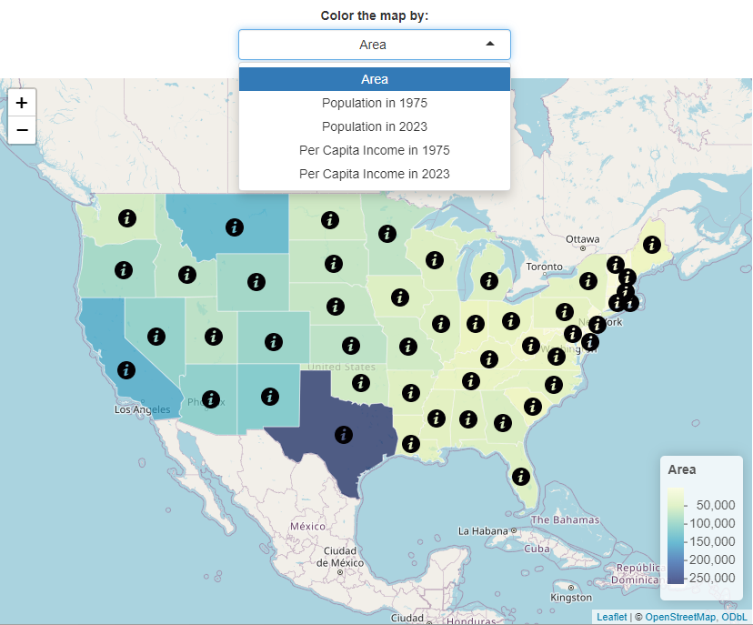

The dropdown box will allow you to select the color based on the data for:  
- the area of each state  
- the population of each state in 1975 and in 2023  
- the per capita income in each state in 1975 and 2023

The map will be updated automatically based on your selection.

If you hover over a state, its name will pop-up for easier identification.

## Understanding the data

You can understand the meaning of each color by looking at the legend on the bottom right of the map.  
The numbers will change depending on your dropdown box selection, but the color scheme will stay the same.

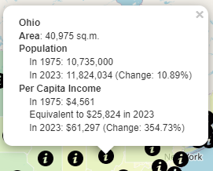

In addition to the information that was color coded, the pop-up will include some calculated values:  
- the change in the state population  
- the adjusted 1975 income in 2023 dollars  
- the change in the income from 1975 to 2023

## 2023 dollars

The inflation adjustment for the 2023 dollars is done with the **priceR** package. If we want to figure out the value of $100 in 1975 dollars adjusted for the year 2023, we can run the following code:

```r
country <- "US"
inputvalue <- 100
originalYear <- 1975
adjustedYear <- 2023
answer <- adjust_for_inflation(inputvalue,
                               originalYear,
                               country,
                               adjustedYear)
```

This helps us get the following answer:  
**$100 in 1975** in US is equivalent to **$566.18** in **2023** due to inflation.

## Use the app

You can find this Shiny app with more documentation in my repository on the [Shiny server](https://a-n-n-a-l.shinyapps.io/shiny/).

The *server.R* and *ui.R* files are available in my [GitHub](https://github.com/a-n-n-a-l/shiny) repository.

[figure not shown]